# Replication 1

Hannah Hardenbergh and Helen Simpson

2/4/2019

# Data Introduction

TABLE 1 Number of Children and Girls for U.S. Courts of Appeals Judges Participating in Gender-Related Cases, 1996-2002

|  | 0 | 1 | 2 | 3 | 4 | 5 | 6 | 7 | 8 | 9 |
| --- | --- | --- | --- | --- | --- | --- | --- | --- | --- | --- |
| Democrat | 12 | 13 | 33 | 24 | 15 | 4 | 0 | 1 | 0 | 1 |
| Republican | 13 | 8 | 44 | 30 | 15 | 7 | 3 | 0 | 1 | 0 |

|  | 0 | 1 | 2 | 3 | 4 | 5 |
| --- | --- | --- | --- | --- | --- | --- |
| 0 | 26 | 35 | 29 | 10 | 1 | 2 |
| 1 | 36 | 43 | 31 | 9 | 2 | 0 |

Demographics of U.S. Court of Appeal Judges who voted on gender-related cases (1996-2002)

|  | All | Democrats | Republicans | Women | Men |
| --- | --- | --- | --- | --- | --- |
| Mean No. Children | 2.47 | 2.40 | 2.54 | 1.58 | 2.66 |
| Mean No. Girls | 1.24 | 1.33 | 1.16 | 0.71 | 1.34 |
| Proportion who have 0 children | 0.11 | 0.12 | 0.11 | 0.29 | 0.08 |
| 1 children | 0.09 | 0.13 | 0.07 | 0.21 | 0.07 |
| 2 children | 0.34 | 0.32 | 0.36 | 0.26 | 0.36 |
| 3 children | 0.24 | 0.23 | 0.25 | 0.13 | 0.26 |
| 4 children | 0.13 | 0.15 | 0.12 | 0.08 | 0.15 |
| 5 Children | 0.05 | 0.04 | 0.06 | 0.03 | 0.05 |
| 6 Children or More | 0.03 | 0.02 | 0.03 | NA | 0.03 |
| Proportion Female | 0.17 | 0.26 | 0.09 | 1.00 | 0.00 |
| Proportion Republican | 0.54 | 0.00 | 1.00 | 0.29 | 0.59 |
| Proportion White | 0.91 | 0.78 | 0.99 | 0.93 | 0.91 |
| Mean Year Born | 1932.55 | 1931.23 | 1933.43 | 1938.57 | 1931.49 |
| N | 224.00 | 103.00 | 121.00 | 38.00 | 186.00 |

[1] 2674

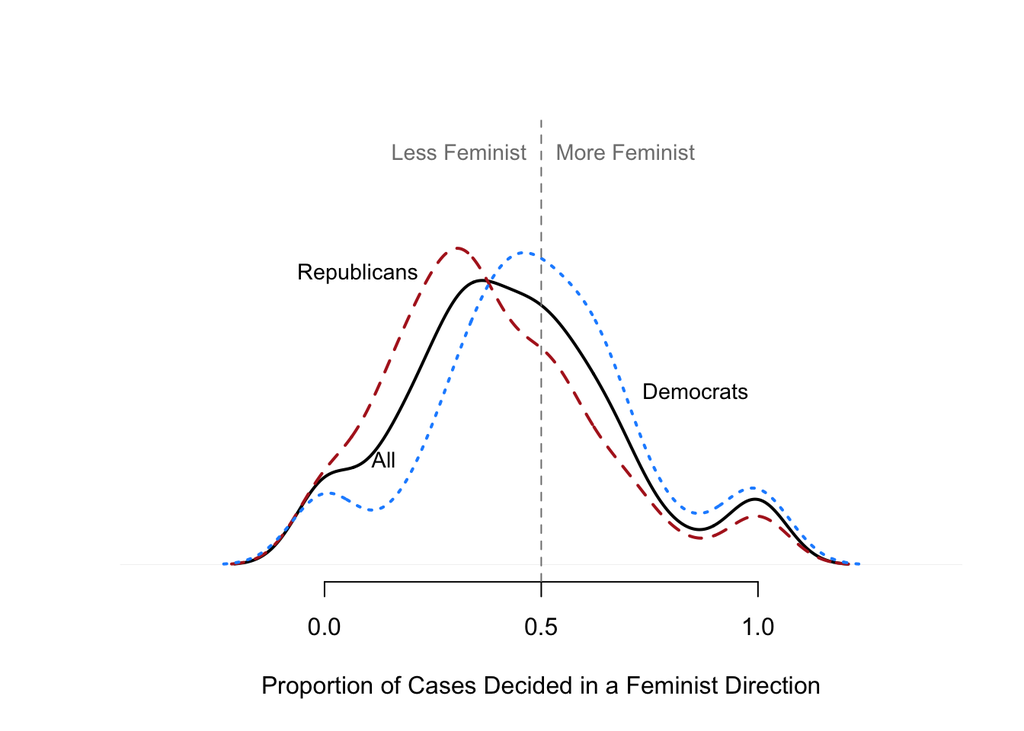

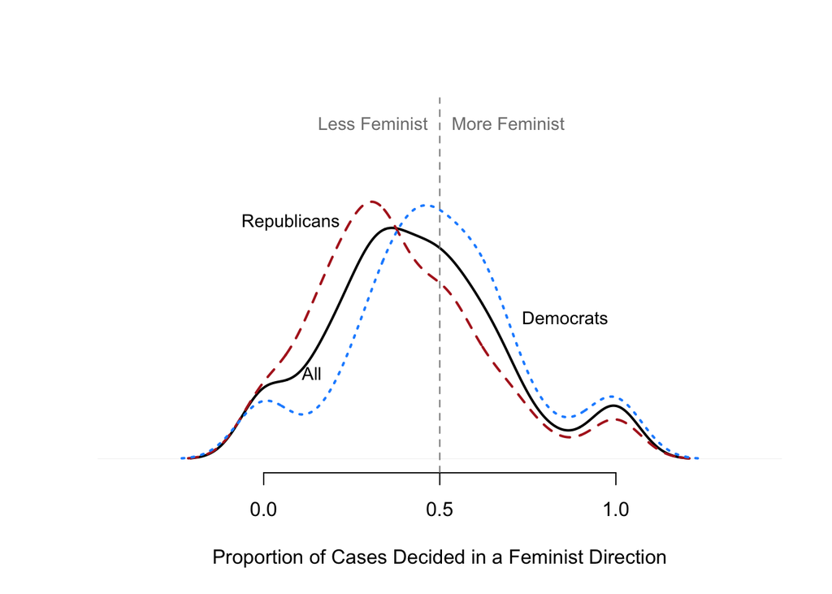

Distribution of the number of gender-related cases heard per judge, 1996-2002.

|  | Min. | 1st Qu. | Median | Mean | 3rd Qu. | Max. |
| --- | --- | --- | --- | --- | --- | --- |
| All Judges | 1 | 5 | 8 | 11.10268 | 14 | 46 |
| Democrats | 1 | 5 | 7 | 10.11650 | 13 | 39 |
| Republicans | 1 | 5 | 9 | 11.94215 | 14 | 46 |

Call: glm(formula = progressive.vote ~ as.factor(girls) + as.factor(child), family = binomial(“logit”), data = subset(women.cases, child < 5 & child > 0))

Deviance Residuals: Min 1Q Median 3Q Max  
-1.0752 -1.0030 -0.9227 1.3042 1.5298

Coefficients: Estimate Std. Error z value Pr(>|z|)  
(Intercept) -0.7986 0.1450 -5.509 3.61e-08 * **as.factor(girls)1 0.3837 0.1277 3.005 0.00266** as.factor(girls)2 0.2036 0.1387 1.468 0.14201  
as.factor(girls)3 0.3458 0.2272 1.522 0.12789  
as.factor(child)2 0.1648 0.1518 1.086 0.27762  
as.factor(child)3 0.1697 0.1658 1.023 0.30627  
as.factor(child)4 0.1594 0.2101 0.759 0.44791  
— Signif. codes: 0 ‘**’ 0.001 ’**’ 0.01 ’’ 0.05 ‘.’ 0.1 ‘’ 1

Call: z5$zelig(formula = progressive.vote ~ as.factor(girls) + as.factor(child), data = subset(women.cases, child < 5 & child > 0))

Deviance Residuals: Min 1Q Median 3Q Max  
-1.0752 -1.0030 -0.9227 1.3042 1.5298

Coefficients: Estimate Std. Error z value Pr(>|z|) (Intercept) -0.7986 0.1450 -5.509 3.61e-08 girls1 0.3837 0.1277 3.005 0.00266 girls2 0.2036 0.1387 1.468 0.14201 girls3 0.3458 0.2272 1.522 0.12789 child2 0.1648 0.1518 1.086 0.27762 child3 0.1697 0.1658 1.023 0.30627 child4 0.1594 0.2101 0.759 0.44791

(Dispersion parameter for binomial family taken to be 1)

```
Null deviance: 2651.6  on 1973  degrees of freedom
```

Residual deviance: 2639.4 on 1967 degrees of freedom (113 observations deleted due to missingness) AIC: 2653.4

Number of Fisher Scoring iterations: 4

Call: glm(formula = progressive.vote ~ I(girls > 0) + as.factor(child), family = binomial(“logit”), data = subset(women.cases, child < 5 & child > 0))

Deviance Residuals: Min 1Q Median 3Q Max  
-1.042 -1.039 -0.919 1.322 1.514

Coefficients: Estimate Std. Error z value Pr(>|z|)  
(Intercept) -0.76360 0.14259 -5.355 8.55e-08 * **I(girls > 0)TRUE 0.31623 0.11932 2.650 0.00804** as.factor(child)2 0.12003 0.14915 0.805 0.42095  
as.factor(child)3 0.11359 0.15935 0.713 0.47594  
as.factor(child)4 0.06728 0.19228 0.350 0.72640  
— Signif. codes: 0 ‘**’ 0.001 ’**’ 0.01 ’’ 0.05 ‘.’ 0.1 ‘’ 1

Call: z5$zelig(formula = progressive.vote ~ I(girls > 0) + as.factor(child), data = subset(women.cases, child < 5 & child > 0))

Deviance Residuals: Min 1Q Median 3Q Max  
-1.042 -1.039 -0.919 1.322 1.514

Coefficients: Estimate Std. Error z value Pr(>|z|) (Intercept) -0.76360 0.14259 -5.355 8.55e-08 I(girls > 0)TRUE 0.31623 0.11932 2.650 0.00804 child2 0.12003 0.14915 0.805 0.42095 child3 0.11359 0.15935 0.713 0.47594 child4 0.06728 0.19228 0.350 0.72640

(Dispersion parameter for binomial family taken to be 1)

```
Null deviance: 2651.6  on 1973  degrees of freedom
```

Residual deviance: 2642.0 on 1969 degrees of freedom (113 observations deleted due to missingness) AIC: 2652

Number of Fisher Scoring iterations: 4

Call: glm(formula = progressive.vote ~ I(girls > 0) + as.factor(child) + republican + age + I(religion == 4) + woman + I(race == 2) + I(race == 3) + as.factor(circuit) + as.factor(year), family = binomial(logit), data = subset(women.cases, child < 5 & child > 0))

Deviance Residuals: Min 1Q Median 3Q Max  
-1.8021 -0.9537 -0.7424 1.2118 1.9806

Coefficients: Estimate Std. Error z value Pr(>|z|)  
(Intercept) -0.41937 0.72630 -0.577 0.563668  
I(girls > 0)TRUE 0.39519 0.16482 2.398 0.016501 *  
as.factor(child)2 0.06256 0.22481 0.278 0.780811  
as.factor(child)3 -0.06981 0.22875 -0.305 0.760237  
as.factor(child)4 -0.16719 0.25830 -0.647 0.517456  
republican -0.69538 0.14949 -4.652 3.29e-06 age 0.01758 0.01085 1.620 0.105293  
I(religion == 4)TRUE -0.19468 0.13868 -1.404 0.160360  
woman -0.07188 0.20632 -0.348 0.727540  
I(race == 2)TRUE -0.17763 0.30624 -0.580 0.561889  
I(race == 3)TRUE -0.64511 0.45051 -1.432 0.152158  
as.factor(circuit)10 -0.99466 0.29351 -3.389 0.000702 as.factor(circuit)11 -0.70466 0.32935 -2.140 0.032388 *  
as.factor(circuit)2 -0.19230 0.35090 -0.548 0.583681  
as.factor(circuit)3 -0.19434 0.34600 -0.562 0.574337  
as.factor(circuit)4 -0.64914 0.32696 -1.985 0.047098 *  
as.factor(circuit)5 -0.64391 0.33317 -1.933 0.053279 .  
as.factor(circuit)6 -1.16463 0.29646 -3.928 8.55e-05 *as.factor(circuit)7 -0.88127 0.26462 -3.330 0.000867* as.factor(circuit)8 -1.14458 0.27842 -4.111 3.94e-05 *** as.factor(circuit)9 -0.27469 0.31931 -0.860 0.389644  
as.factor(circuit)DC 0.66491 0.43487 1.529 0.126267  
as.factor(year)1997 -0.05015 0.24909 -0.201 0.840424  
as.factor(year)1998 0.44606 0.24608 1.813 0.069891 .  
as.factor(year)1999 0.17555 0.25409 0.691 0.489632  
as.factor(year)2000 0.16567 0.25591 0.647 0.517380  
as.factor(year)2001 -0.11036 0.24875 -0.444 0.657301  
as.factor(year)2002 -0.37695 0.24811 -1.519 0.128686  
— Signif. codes: 0 ‘**’ 0.001 ’**’ 0.01 ’’ 0.05 ‘.’ 0.1 ‘’ 1

Call: z5$zelig(formula = progressive.vote ~ I(girls > 0) + as.factor(child) + republican + age + I(religion == 4) + woman + I(race == 2) + I(race == 3) + as.factor(circuit) + as.factor(year), data = subset(women.cases, child < 5 & child > 0))

Deviance Residuals: Min 1Q Median 3Q Max  
-1.8021 -0.9537 -0.7424 1.2118 1.9806

Coefficients: Estimate Std. Error z value Pr(>|z|) (Intercept) -0.41937 0.72630 -0.577 0.563668 I(girls > 0)TRUE 0.39519 0.16482 2.398 0.016501 child2 0.06256 0.22481 0.278 0.780811 child3 -0.06981 0.22875 -0.305 0.760237 child4 -0.16719 0.25830 -0.647 0.517456 republican -0.69538 0.14949 -4.652 3.29e-06 age 0.01758 0.01085 1.620 0.105293 I(religion == 4)TRUE -0.19468 0.13868 -1.404 0.160360 woman -0.07188 0.20632 -0.348 0.727540 I(race == 2)TRUE -0.17763 0.30624 -0.580 0.561889 I(race == 3)TRUE -0.64511 0.45051 -1.432 0.152158 circuit10 -0.99466 0.29351 -3.389 0.000702 circuit11 -0.70466 0.32935 -2.140 0.032388 circuit2 -0.19230 0.35090 -0.548 0.583681 circuit3 -0.19434 0.34600 -0.562 0.574337 circuit4 -0.64914 0.32696 -1.985 0.047098 circuit5 -0.64391 0.33317 -1.933 0.053279 circuit6 -1.16463 0.29646 -3.928 8.55e-05 circuit7 -0.88127 0.26462 -3.330 0.000867 circuit8 -1.14458 0.27842 -4.111 3.94e-05 circuit9 -0.27469 0.31931 -0.860 0.389644 circuitDC 0.66491 0.43487 1.529 0.126267 year1997 -0.05015 0.24909 -0.201 0.840424 year1998 0.44606 0.24608 1.813 0.069891 year1999 0.17555 0.25409 0.691 0.489632 year2000 0.16567 0.25591 0.647 0.517380 year2001 -0.11036 0.24875 -0.444 0.657301 year2002 -0.37695 0.24811 -1.519 0.128686

(Dispersion parameter for binomial family taken to be 1)

```
Null deviance: 1996.9  on 1506  degrees of freedom
```

Residual deviance: 1882.8 on 1479 degrees of freedom (580 observations deleted due to missingness) AIC: 1938.8

Number of Fisher Scoring iterations: 4

Call: glm(formula = progressive.vote ~ I(girls > 0) + as.factor(child) + republican + age + I(religion == 4) + woman + I(race == 2) + I(race == 3) + as.factor(circuit) + as.factor(year) + as.factor(area), family = binomial(“logit”), data = subset(women.cases, child < 5 & child > 0))

Deviance Residuals: Min 1Q Median 3Q Max  
-1.8404 -0.9365 -0.7284 1.1972 1.9992

Coefficients: Estimate Std. Error z value Pr(>|z|) (Intercept) 1.12339 0.88529 1.269 0.204462 I(girls > 0)TRUE 0.42267 0.16673 2.535 0.011243 as.factor(child)2 0.06065 0.22644 0.268 0.788819 as.factor(child)3 -0.05944 0.23080 -0.258 0.796762 as.factor(child)4 -0.17771 0.26038 -0.682 0.494925 republican -0.68488 0.15079 -4.542 5.57e-06 age 0.01655 0.01097 1.509 0.131175 I(religion == 4)TRUE -0.20994 0.13975 -1.502 0.133032 woman -0.09854 0.20769 -0.474 0.635184 I(race == 2)TRUE -0.20146 0.30891 -0.652 0.514299 I(race == 3)TRUE -0.64917 0.45397 -1.430 0.152715 as.factor(circuit)10 -0.99488 0.29534 -3.369 0.000756 as.factor(circuit)11 -0.72015 0.33145 -2.173 0.029801 as.factor(circuit)2 -0.18276 0.35213 -0.519 0.603745 as.factor(circuit)3 -0.18752 0.35252 -0.532 0.594764 as.factor(circuit)4 -0.71586 0.33221 -2.155 0.031176 as.factor(circuit)5 -0.62176 0.33682 -1.846 0.064895 as.factor(circuit)6 -1.16941 0.29842 -3.919 8.90e-05 as.factor(circuit)7 -0.90599 0.26798 -3.381 0.000723 as.factor(circuit)8 -1.19367 0.28118 -4.245 2.18e-05 as.factor(circuit)9 -0.32127 0.32222 -0.997 0.318738 as.factor(circuit)DC 0.65913 0.44102 1.495 0.135030 as.factor(year)1997 -0.04699 0.25399 -0.185 0.853226 as.factor(year)1998 0.47003 0.25061 1.876 0.060715 as.factor(year)1999 0.20844 0.25874 0.806 0.420474 as.factor(year)2000 0.16978 0.26064 0.651 0.514785 as.factor(year)2001 -0.08748 0.25385 -0.345 0.730388 as.factor(year)2002 -0.33977 0.25362 -1.340 0.180345 as.factor(area)employment -1.54255 0.50063 -3.081 0.002062 as.factor(area)pregnancy -1.72810 0.54545 -3.168 0.001534 as.factor(area)reproductive rights -1.43363 1.15573 -1.240 0.214807 as.factor(area)Title IX -0.28528 0.69500 -0.410 0.681457

(Intercept)  
I(girls > 0)TRUE *  
as.factor(child)2  
as.factor(child)3  
as.factor(child)4  
republican age  
I(religion == 4)TRUE  
woman  
I(race == 2)TRUE  
I(race == 3)TRUE  
as.factor(circuit)10 as.factor(circuit)11 *  
as.factor(circuit)2  
as.factor(circuit)3  
as.factor(circuit)4 *  
as.factor(circuit)5 .  
as.factor(circuit)6 *as.factor(circuit)7* as.factor(circuit)8 * as.factor(circuit)9  
as.factor(circuit)DC  
as.factor(year)1997  
as.factor(year)1998 .  
as.factor(year)1999  
as.factor(year)2000  
as.factor(year)2001  
as.factor(year)2002  
as.factor(area)employment as.factor(area)pregnancy ** as.factor(area)reproductive rights  
as.factor(area)Title IX  
— Signif. codes: 0 ‘**’ 0.001 ’**’ 0.01 ’’ 0.05 ‘.’ 0.1 ‘’ 1

Call: z5$zelig(formula = progressive.vote ~ I(girls > 0) + as.factor(child) + republican + age + I(religion == 4) + woman + I(race == 2) + I(race == 3) + as.factor(circuit) + as.factor(year) + as.factor(area), data = subset(women.cases, child < 5 & child > 0))

Deviance Residuals: Min 1Q Median 3Q Max  
-1.8404 -0.9365 -0.7284 1.1972 1.9992

Coefficients: Estimate Std. Error z value Pr(>|z|) (Intercept) 1.12339 0.88529 1.269 0.204462 I(girls > 0)TRUE 0.42267 0.16673 2.535 0.011243 child2 0.06065 0.22644 0.268 0.788819 child3 -0.05944 0.23080 -0.258 0.796762 child4 -0.17771 0.26038 -0.682 0.494925 republican -0.68488 0.15079 -4.542 5.57e-06 age 0.01655 0.01097 1.509 0.131175 I(religion == 4)TRUE -0.20994 0.13975 -1.502 0.133032 woman -0.09854 0.20769 -0.474 0.635184 I(race == 2)TRUE -0.20146 0.30891 -0.652 0.514299 I(race == 3)TRUE -0.64917 0.45397 -1.430 0.152715 circuit10 -0.99488 0.29534 -3.369 0.000756 circuit11 -0.72015 0.33145 -2.173 0.029801 circuit2 -0.18276 0.35213 -0.519 0.603745 circuit3 -0.18752 0.35252 -0.532 0.594764 circuit4 -0.71586 0.33221 -2.155 0.031176 circuit5 -0.62176 0.33682 -1.846 0.064895 circuit6 -1.16941 0.29842 -3.919 8.90e-05 circuit7 -0.90599 0.26798 -3.381 0.000723 circuit8 -1.19367 0.28118 -4.245 2.18e-05 circuit9 -0.32127 0.32222 -0.997 0.318738 circuitDC 0.65913 0.44102 1.495 0.135030 year1997 -0.04699 0.25399 -0.185 0.853226 year1998 0.47003 0.25061 1.876 0.060715 year1999 0.20844 0.25874 0.806 0.420474 year2000 0.16978 0.26064 0.651 0.514785 year2001 -0.08748 0.25385 -0.345 0.730388 year2002 -0.33977 0.25362 -1.340 0.180345 areaemployment -1.54255 0.50063 -3.081 0.002062 areapregnancy -1.72810 0.54545 -3.168 0.001534 areareproductive rights -1.43363 1.15573 -1.240 0.214807 areaTitle IX -0.28528 0.69500 -0.410 0.681457

(Dispersion parameter for binomial family taken to be 1)

```
Null deviance: 1996.9  on 1506  degrees of freedom
```

Residual deviance: 1864.1 on 1475 degrees of freedom (580 observations deleted due to missingness) AIC: 1928.1

Number of Fisher Scoring iterations: 4

Coefficients: Value Std. Error t value I(girls > 0)TRUE 0.431611 0.16433 2.62642 child2 0.007936 0.21967 0.03613 child3 -0.136250 0.22380 -0.60881 child4 -0.251958 0.25251 -0.99780 republican -0.639710 0.14483 -4.41701 age 0.022306 0.01053 2.11769 I(religion == 4)TRUE -0.190449 0.13445 -1.41650 woman -0.074625 0.19985 -0.37341 I(race == 2)TRUE -0.226530 0.29303 -0.77306 I(race == 3)TRUE -0.720202 0.44134 -1.63185 circuit10 -1.021190 0.27703 -3.68617 circuit11 -0.535073 0.31225 -1.71362 circuit2 -0.105075 0.32919 -0.31919 circuit3 -0.115078 0.33201 -0.34662 circuit4 -0.529805 0.31779 -1.66717 circuit5 -0.653390 0.31565 -2.06998 circuit6 -1.063996 0.28254 -3.76581 circuit7 -0.730720 0.25178 -2.90217 circuit8 -1.177122 0.26366 -4.46447 circuit9 -0.228835 0.29827 -0.76721 circuitDC 0.536653 0.38811 1.38272 year1997 -0.078363 0.24454 -0.32044 year1998 0.415853 0.23932 1.73768 year1999 0.292050 0.24955 1.17032 year2000 0.082663 0.25076 0.32964 year2001 -0.115828 0.24442 -0.47389 year2002 -0.391958 0.24496 -1.60009 areaemployment -2.170673 0.50192 -4.32470 areapregnancy -2.293917 0.54412 -4.21579 areareproductive rights -2.516791 1.04775 -2.40210 areaTitle IX -1.158857 0.64519 -1.79616

Intercepts: Value Std. Error t value 1|2 -1.4266 0.8610 -1.6569 2|3 -0.5526 0.8602 -0.6424 3|4 16.6921 0.8604 19.4006

Residual Deviance: 2625.301 AIC: 2693.301 (580 observations deleted due to missingness) Next step: Use ‘setx’ method

Call: lm(formula = lib_vote_share ~ I(girls > 0) * republican + as.factor(child), data = judge.means, weights = judge.means$no_cases)

Weighted Residuals: Min 1Q Median 3Q Max -1.3365 -0.3898 0.0000 0.4128 1.5580

Coefficients: Estimate Std. Error t value Pr(>|t|)  
(Intercept) 0.457628 0.044297 10.331 <2e-16 ** I(girls > 0)TRUE 0.080231 0.047784 1.679 0.0946 .  
republican -0.103252 0.045306 -2.279 0.0237  
as.factor(child)1 -0.087289 0.052816 -1.653 0.0999 .  
as.factor(child)2 -0.037222 0.046914 -0.793 0.4284  
as.factor(child)3 -0.046904 0.050958 -0.920 0.3584  
as.factor(child)4 -0.039967 0.060642 -0.659 0.5106  
as.factor(child)5 -0.005645 0.068286 -0.083 0.9342  
as.factor(child)6 0.139921 0.117320 1.193 0.2344  
as.factor(child)7 -0.061668 0.140579 -0.439 0.6614  
as.factor(child)8 -0.224663 0.250637 -0.896 0.3711  
as.factor(child)9 -0.037858 0.158598 -0.239 0.8116  
I(girls > 0)TRUE:republican -0.043277 0.054270 -0.797 0.4261  
— Signif. codes: 0 ‘**’ 0.001 ’**’ 0.01 ’’ 0.05 ‘.’ 0.1 ‘’ 1

Residual standard error: 0.6019 on 211 degrees of freedom Multiple R-squared: 0.1532, Adjusted R-squared: 0.1051 F-statistic: 3.182 on 12 and 211 DF, p-value: 0.0003351

Call: lm(formula = lib_vote_share ~ I(girls > 0) + as.factor(child), data = rep.means, weights = rep.means$no_cases)

Weighted Residuals: Min 1Q Median 3Q Max -1.19419 -0.35846 0.05667 0.43992 1.29425

Coefficients: Estimate Std. Error t value Pr(>|t|)  
(Intercept) 0.295663 0.055643 5.314 7.46e-07 *** I(girls > 0)TRUE 0.070163 0.041881 1.675 0.0973 .  
as.factor(child)2 -0.004942 0.059040 -0.084 0.9335  
as.factor(child)3 -0.007370 0.063081 -0.117 0.9072  
as.factor(child)4 -0.065210 0.073496 -0.887 0.3773  
— Signif. codes: 0 ‘**’ 0.001 ’**’ 0.01 ’’ 0.05 ‘.’ 0.1 ‘’ 1

Residual standard error: 0.5768 on 92 degrees of freedom Multiple R-squared: 0.03803, Adjusted R-squared: -0.003796 F-statistic: 0.9092 on 4 and 92 DF, p-value: 0.462

Call: lm(formula = lib_vote_share ~ I(girls > 0) + as.factor(child), data = dem.means, weights = dem.means$no_cases)

Weighted Residuals: Min 1Q Median 3Q Max -1.1731 -0.3931 0.0081 0.3267 1.6014

Coefficients: Estimate Std. Error t value Pr(>|t|)  
(Intercept) 0.35333 0.05542 6.375 1.09e-08 ** I(girls > 0)TRUE 0.04160 0.05374 0.774 0.4411  
as.factor(child)2 0.10176 0.05880 1.731 0.0874 .  
as.factor(child)3 0.08400 0.06315 1.330 0.1873  
as.factor(child)4 0.18985 0.08110 2.341 0.0217  
— Signif. codes: 0 ‘**’ 0.001 ’**’ 0.01 ’’ 0.05 ‘.’ 0.1 ‘’ 1

Residual standard error: 0.574 on 80 degrees of freedom Multiple R-squared: 0.09221, Adjusted R-squared: 0.04683 F-statistic: 2.032 on 4 and 80 DF, p-value: 0.09781

Call: lm(formula = lib_vote_share ~ I(girls > 0) * woman + as.factor(child), data = judge.means, weights = judge.means$no_cases)

Weighted Residuals: Min 1Q Median 3Q Max -1.58075 -0.40588 0.06165 0.45383 1.83482

Coefficients: Estimate Std. Error t value Pr(>|t|)  
(Intercept) 0.37673 0.04022 9.366 <2e-16 ** *I(girls > 0)TRUE 0.08135 0.03738 2.176 0.0306*  
woman 0.04796 0.05191 0.924 0.3566  
as.factor(child)1 -0.07771 0.05622 -1.382 0.1684  
as.factor(child)2 -0.03943 0.05034 -0.783 0.4343  
as.factor(child)3 -0.04389 0.05446 -0.806 0.4212  
as.factor(child)4 -0.05221 0.06480 -0.806 0.4214  
as.factor(child)5 -0.02261 0.07293 -0.310 0.7569  
as.factor(child)6 0.07317 0.12416 0.589 0.5563  
as.factor(child)7 0.01811 0.14874 0.122 0.9032  
as.factor(child)8 -0.29141 0.26625 -1.095 0.2750  
as.factor(child)9 0.04192 0.16798 0.250 0.8032  
I(girls > 0)TRUE:woman -0.04415 0.07000 -0.631 0.5289  
— Signif. codes: 0 ‘**’ 0.001 ’**’ 0.01 ’’ 0.05 ‘.’ 0.1 ‘’ 1

Residual standard error: 0.64 on 211 degrees of freedom Multiple R-squared: 0.04241, Adjusted R-squared: -0.01205 F-statistic: 0.7787 on 12 and 211 DF, p-value: 0.6721

Call: lm(formula = lib_vote_share ~ I(girls > 0) + as.factor(child), data = men.means, weights = men.means$no_cases)

Weighted Residuals: Min 1Q Median 3Q Max -1.59762 -0.36484 0.06268 0.48662 1.80911

Coefficients: Estimate Std. Error t value Pr(>|t|)  
(Intercept) 0.30473 0.05601 5.441 2.09e-07 ** *I(girls > 0)TRUE 0.08081 0.04033 2.004 0.0469*  
as.factor(child)2 0.02838 0.05489 0.517 0.6059  
as.factor(child)3 0.03578 0.05773 0.620 0.5364  
as.factor(child)4 0.02352 0.06846 0.344 0.7316  
— Signif. codes: 0 ‘**’ 0.001 ’**’ 0.01 ’’ 0.05 ‘.’ 0.1 ‘’ 1

Residual standard error: 0.6294 on 151 degrees of freedom Multiple R-squared: 0.03208, Adjusted R-squared: 0.006439 F-statistic: 1.251 on 4 and 151 DF, p-value: 0.2919

Call: lm(formula = lib_vote_share ~ I(girls > 0) + as.factor(child), data = women.means, weights = women.means$no_cases)

Weighted Residuals: Min 1Q Median 3Q Max -1.16894 -0.29168 -0.06597 0.30352 1.50994

Coefficients: Estimate Std. Error t value Pr(>|t|)  
(Intercept) 0.33606 0.06323 5.315 2.86e-05 *** I(girls > 0)TRUE 0.04751 0.08239 0.577 0.570  
as.factor(child)2 0.07641 0.09179 0.832 0.415  
as.factor(child)3 -0.01343 0.10104 -0.133 0.895  
as.factor(child)4 0.01178 0.12520 0.094 0.926  
— Signif. codes: 0 ‘**’ 0.001 ’**’ 0.01 ’’ 0.05 ‘.’ 0.1 ‘’ 1

Residual standard error: 0.6082 on 21 degrees of freedom Multiple R-squared: 0.08251, Adjusted R-squared: -0.09225 F-statistic: 0.4721 on 4 and 21 DF, p-value: 0.7556

Call: lm(formula = lib_vote_share ~ I(girls > 0) + as.factor(child), data = subset(men.means, republican == 1), weights = men.means$no_cases[which(men.means$republican == 1)])

Weighted Residuals: Min 1Q Median 3Q Max -1.20258 -0.35211 0.03609 0.49800 1.28933

Coefficients: Estimate Std. Error t value Pr(>|t|)  
(Intercept) 0.275709 0.066839 4.125 8.6e-05 *** I(girls > 0)TRUE 0.077840 0.044824 1.737 0.0861 .  
as.factor(child)2 0.016570 0.066816 0.248 0.8047  
as.factor(child)3 0.008013 0.070411 0.114 0.9097  
as.factor(child)4 -0.057920 0.081932 -0.707 0.4815  
— Signif. codes: 0 ‘**’ 0.001 ’**’ 0.01 ’’ 0.05 ‘.’ 0.1 ‘’ 1

Residual standard error: 0.5897 on 85 degrees of freedom Multiple R-squared: 0.04617, Adjusted R-squared: 0.00128 F-statistic: 1.029 on 4 and 85 DF, p-value: 0.3974

Call: lm(formula = lib_vote_share ~ I(girls > 0) + as.factor(child), data = subset(judge.means, child < 2), weights = judge.means$no_cases[which(judge.means$child < 2)])

Weighted Residuals: Min 1Q Median 3Q Max -1.2669 -0.3833 -0.0008 0.4839 1.3837

Coefficients: Estimate Std. Error t value Pr(>|t|)  
(Intercept) 0.39297 0.03677 10.689 1.1e-13 ** *I(girls > 0)TRUE 0.16104 0.07977 2.019 0.0498*  
as.factor(child)1 -0.11890 0.06697 -1.775 0.0829 .  
— Signif. codes: 0 ‘**’ 0.001 ’**’ 0.01 ’’ 0.05 ‘.’ 0.1 ‘’ 1

Residual standard error: 0.6504 on 43 degrees of freedom Multiple R-squared: 0.09679, Adjusted R-squared: 0.05478 F-statistic: 2.304 on 2 and 43 DF, p-value: 0.1121

Call: lm(formula = lib_vote_share ~ I(girls > 0), data = subset(judge.means, child == 1), weights = judge.means$no_cases[which(judge.means$child == 1)])

Weighted Residuals: Min 1Q Median 3Q Max -1.0141 -0.3472 -0.1360 0.3810 1.3837

Coefficients: Estimate Std. Error t value Pr(>|t|)  
(Intercept) 0.27407 0.04745 5.776 1.45e-05 ** *I(girls > 0)TRUE 0.16104 0.06761 2.382 0.0278*  
— Signif. codes: 0 ‘**’ 0.001 ’**’ 0.01 ’’ 0.05 ‘.’ 0.1 ‘’ 1

Residual standard error: 0.5513 on 19 degrees of freedom Multiple R-squared: 0.2299, Adjusted R-squared: 0.1894 F-statistic: 5.673 on 1 and 19 DF, p-value: 0.02784

Call: lm(formula = lib_vote_share ~ I(girls > 0) + I(republican == 1), data = subset(judge.means, child == 1), weights = judge.means$no_cases[which(judge.means$child == 1)])

Weighted Residuals: Min 1Q Median 3Q Max -0.9371 -0.3954 -0.1271 0.4582 1.3446

Coefficients: Estimate Std. Error t value Pr(>|t|)  
(Intercept) 0.29232 0.05904 4.951 0.000103 ** *I(girls > 0)TRUE 0.15875 0.06904 2.299 0.033679*  
I(republican == 1)TRUE -0.03732 0.06927 -0.539 0.596691  
— Signif. codes: 0 ‘**’ 0.001 ’**’ 0.01 ’’ 0.05 ‘.’ 0.1 ‘’ 1

Residual standard error: 0.5619 on 18 degrees of freedom Multiple R-squared: 0.2421, Adjusted R-squared: 0.1579 F-statistic: 2.876 on 2 and 18 DF, p-value: 0.08247

|  | 0 Girls | 1 Girl | 2 Girls | 3 Girls | 4 Girls | 5 Girls | 0 Girls | 1 Girl | 2 Girls | 3 Girls | 4 Girls |
| --- | --- | --- | --- | --- | --- | --- | --- | --- | --- | --- | --- |
| 0 | 1.0000000 | 0.0000000 | 0.0000000 | 0.0000000 | 0 | 0.00 | 1.0000000 | 0.0000000 | 0.0000000 | 0.0000000 | 0.0000000 |
| 1 | 0.4615385 | 0.5384615 | 0.0000000 | 0.0000000 | 0 | 0.00 | 0.3750000 | 0.6250000 | 0.0000000 | 0.0000000 | 0.0000000 |
| 2 | 0.1515152 | 0.4848485 | 0.3636364 | 0.0000000 | 0 | 0.00 | 0.3181818 | 0.5000000 | 0.1818182 | 0.0000000 | 0.0000000 |
| 3 | 0.0833333 | 0.4583333 | 0.3333333 | 0.1250000 | 0 | 0.00 | 0.1333333 | 0.3666667 | 0.3666667 | 0.1333333 | 0.0000000 |
| 4 | 0.0666667 | 0.0666667 | 0.5333333 | 0.3333333 | 0 | 0.00 | 0.0666667 | 0.2666667 | 0.6000000 | 0.0666667 | 0.0000000 |
| 5 | 0.0000000 | 0.0000000 | 0.2500000 | 0.5000000 | 0 | 0.25 | 0.1428571 | 0.0000000 | 0.4285714 | 0.2857143 | 0.1428571 |
| 7 | 0.0000000 | 0.0000000 | 0.0000000 | 0.0000000 | 1 | 0.00 | 0.0000000 | 0.3333333 | 0.0000000 | 0.6666667 | 0.0000000 |
| 9 | 0.0000000 | 0.0000000 | 0.0000000 | 0.0000000 | 0 | 1.00 | 0.0000000 | 0.0000000 | 0.0000000 | 0.0000000 | 1.0000000 |